Sep 29, 2018 4:30:22 PM

# Running information

## **Configure information**

## Input file: test.R1.fastq Min reads length: 16 Output folder: . Max reads length: 20 Output prefix: Test Match score: 1 Genome file: /public/home/hjiang/THP1/Hg19.clean.fna MisMatch score: -1 Genome index prefix: /public/home/hjiang/THP1/Hg19 InDel score: -1 HalfLinkerA: GTCGGAGAACCAGTAGCT Resolution: 1000000 2000000 HalfLinkerB: Thread: 4 Restriction: T^TAA

## **Linker filtering**

## Adapter Sequence: GATCGGAAGAGCACACGTCTGAACTCCAGTCACCGATGTATCTCGTATGCCGTCTTCTGCTTGAAAAAACCCC Total reads: 250,000 100.00% AA: 217,045 86.82% Ambiguous: 32,955 13.18% Output folder: ./PreProcess

## **Mapping**

### AA

## Item File path Number Percentage Fastq file R1: ./SeProcess/Test.AA.R1.fastq 217,007 100.00% Fastq file R2: ./SeProcess/Test.AA.R2.fastq 217,007 100.00% Unique map R1: ./SeProcess/Test.AA.R1.0.sort.bed 145,665 67.12% Unique map R2: ./SeProcess/Test.AA.R2.0.sort.bed 151,901 70.00% Merge: ./SeProcess/Test.AA.bedpe 107,885 49.71% Output folder: ./SeProcess

## **Ligation filtering**

### AA

## Item File path Number Percentage SelfLigation: ./BedpeProcess/AA/Ligation/Test.AA.self.bedpe 564 0.52% RelLigation: ./BedpeProcess/AA/Ligation/Test.AA.rel.bedpe 223 0.21% Valid data: 107,098 99.27% No-dump: ./BedpeProcess/AA/Clean/Test.AA.final.bedpe 102,416 94.93% Output folder: ./BedpeProcess/AA

## **InterAction**

## Item Number Percentage Total action: 102,416 40.97% Inter action: 34,421 33.61% Intra action: 67,995 66.39% Short region: 7,839 11.53% Long region: 60,156 88.47%

# Running statistics

### Running time

## Item Value(h/m/s) Start time: Sep 29, 2018 4:29:54 PM Linker filtering: 0H0M1S Mapping: 0H0M0S Ligation filtering: 0H0M0S Make matrix: 0H0M0S Translocation detection: 0H0M0S Total: 0H0M1S

# Linker filtering report

## Linker alignment score distribution

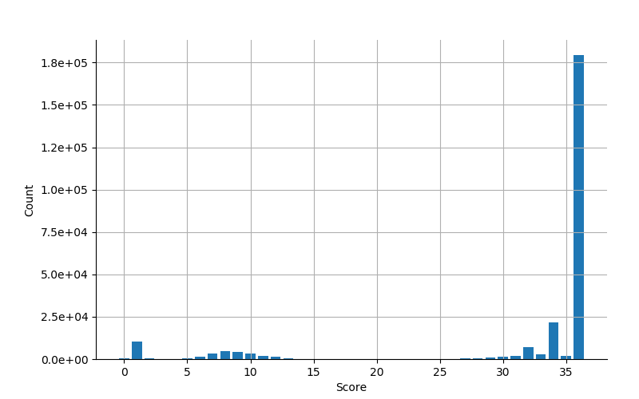

## Tag length distribution

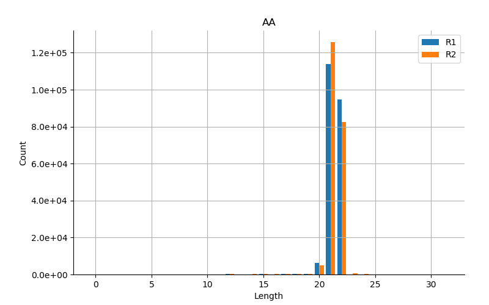

# Mapping report

# Span distribution

### Fragment length statistics

[interactive chart not shown]

### PETs span distribution

[figure not shown]

### Difference of PET span distributions between strands combination -+ and average number of (++, +- and --)

[figure not shown]

### Log-log plot of difference of PET span distribution

[figure not shown]

# Cluster visualization

## Interaction distance distribution

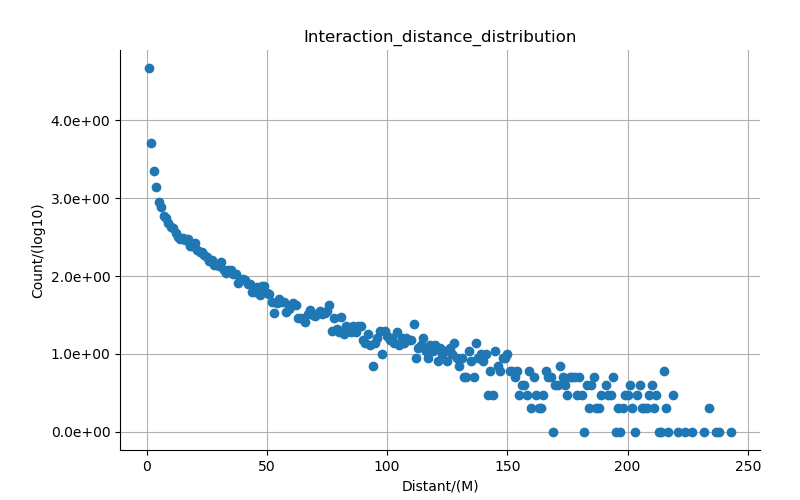

## Interaction heatmap

### Resolution 1,000,000

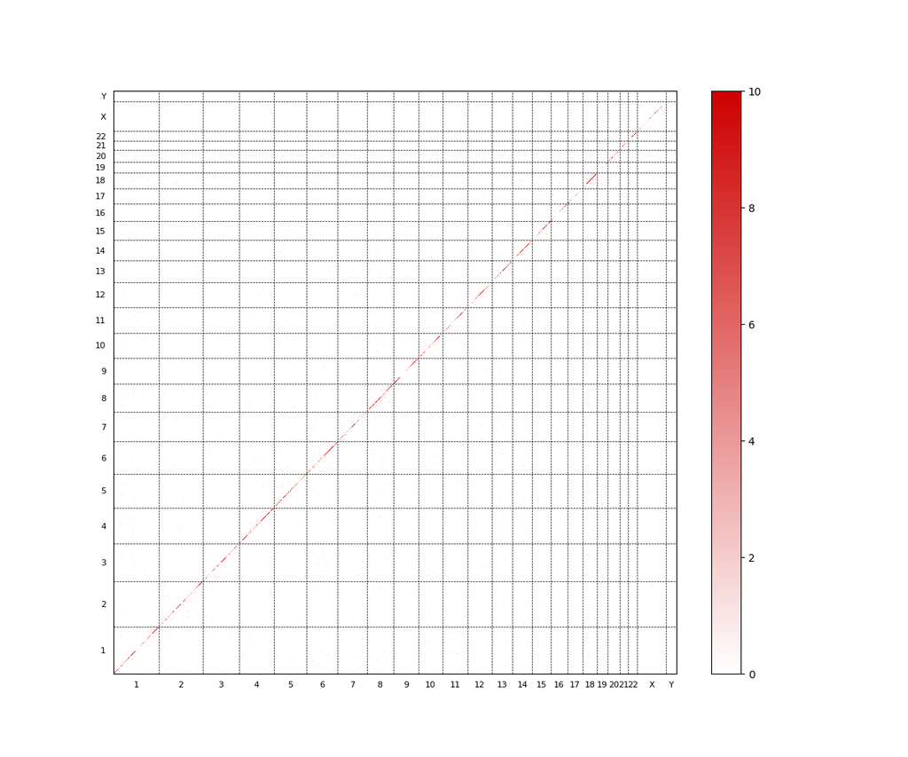

### Resolution 2,000,000

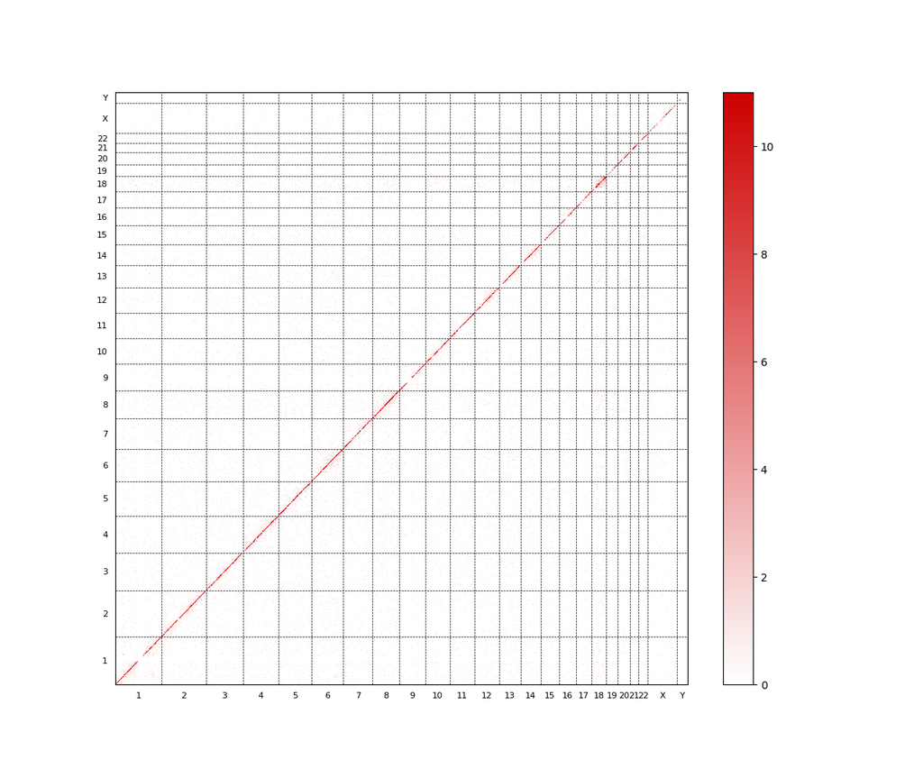

1. Please use Chrome, Firefox or Safari for better browsing experience.

2. Detailed explanation can be found at https://github.com/GuoliangLi-HZAU/ChIA-PET_Tool.